# Slide-Desk-Report-on-Analytics-of-MoH-Breast-Cancer-Data slides

## Slide Desk Report on Analytics of MoH Breast Cancer Data

## Research Overview

> The primary goal of this research is to perform an Exploratory and Explanatory Data Analytics on Breast Cancer dataset in order to get insights on the relationship among breast cancer attributes.

## Dataset Overview

> The dataset used in this research was collected from Ministry of Health, King Fahd Medical City Hospital, Saudi Arabia. The dataset include patient age, cancer type, grade, breast density, breast imaging reporting and data system (BIRADS) among others. It contains 521 instances and 16 features.

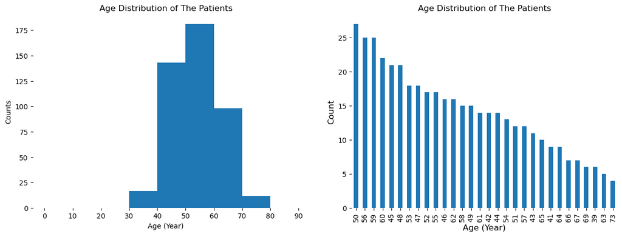

## Cancer Stage Distribution of The Patients

> T1N0M0 is the major breast cancer stage exhibited by the patients, 36.56% of the patients belong to this satge, followed by T2N0M0 and T2N1M0 with 13.66% and 11.45% respectively. For the majority of the patients to belong to the early-stage primary pulmonary adenocarcinoma (T1N0M0), one can deduce that potential breast cancer patients do go for a early test to know their status, this could be associated with breast cancer sensitisation and awareness in the area under study.

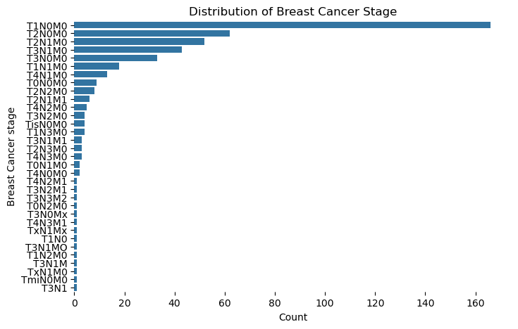

## Cancer Grade Distribution of The Patients

> Breast cancer grade II appears to be the major cancer grade exhibited by the patients as 61.89% of them belong to this grade, follwoed by cancer grade III with 29.96%, and cancer grade I with 8.15%.  
> Th breast cancer grade II implies that the cancer has grown, but hasn't spread. For the percentage of the patients to have reduced to 32% from cancer grade II to cancer grade III, one can analytically say that there is a huge positive result in the cancer treatments.

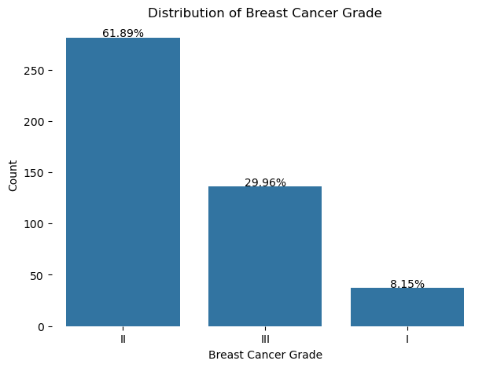

## Distribution of Breast Imaging Reporting and Data System (BIRADS)

> The data revealed that 53.30% of the patients fall under BIRADS category 0, which implies an imcomplete test, that is, additional imaging evaluation and/or comparison to prior mammograms (or other imaging tests) is needed to ascertain the beast cancer status. While, 42.73% of the patients fall in BIRADS category V.

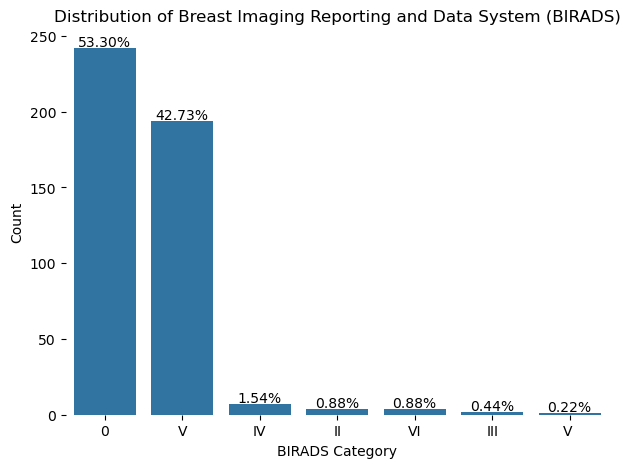

## Cancer Type Distribution of The Patients

> The data revealed that 41.51% of the patient exhibited both Invasive Ductal Carcinoma and Ductal Carcinoma In Situ Component (IDC + DCIS) cancer type, while 36.47% of them have only Invasive Ductal Carcinoma (IDC) cancer type. This implies that each of this breast cancer type can often be present alone or co-exist with each other as IDC + DCIS. Only 4.13% of the patients have Invasive Lobular Carcinoma (ILC) type.

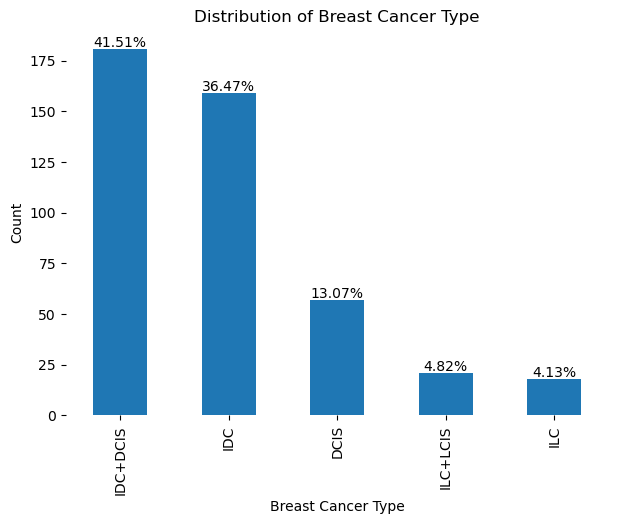

## Correlation Among All The variables

> Positive correlations were observed between cancer grade and stage, birads and stage, type and ultrasound. It appears that age is nagatively correlated with cancer stage, grade, breast density and calcification, but positively correlated with cancer type, ultrasound and birads. However, the correlations as either positive or negative are both at minimal levels, which further confirmed the fact that age is not a strong determinant of breast cancer stage, type, grade or breast density.

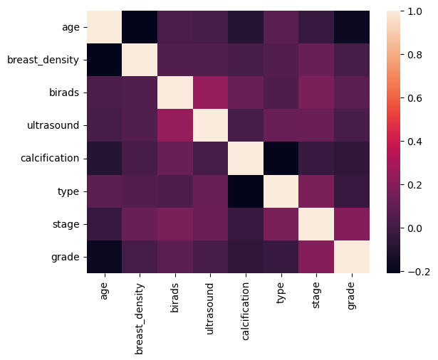

## KEY INSIGHTS

After an In-depth analysis, the following insights were revealed by the data.

> - Breast cancer rarely affect women below the age of 30.
> - The most vulnerable age group of breast cancer is between 50 - 60 years old.
> - Majority of the patients belong to the early-stage primary pulmonary adenocarcinoma (T1N0M0) cancer stage, which signifies the chances of the patients having an early breast cancer test.
> - 61.89% of the patients fall under cancer grade II, while only 29.96% of them fall under cancer grade III, the 32% reduction of patients from cancer grade II to cancer grade III signifies a posible positive response to breast cancer treatments.
> - There is a positive correlations between cancer grade and stage, birads and stage, while a negative correlations were also observed between age and cancer stage, grade and breast density.